# 2020 Q

Jake Cavaiani

11/13/2020

### 2020

2020 (Moose, French, Poker, Vault, Stuart), and 2021 (Moose, French, Poker, Vault, Stuart), clean out of water points, potentially erroneous points collected, beaver dams, etc. and prepare to convert to continuous predicted discharge (Q) throuhgout the year.

2020 data is read in from DoD Project->2020 AK sensors->Discharge->Pressure Transducer->Water Level->“site”

## Comparing PTs

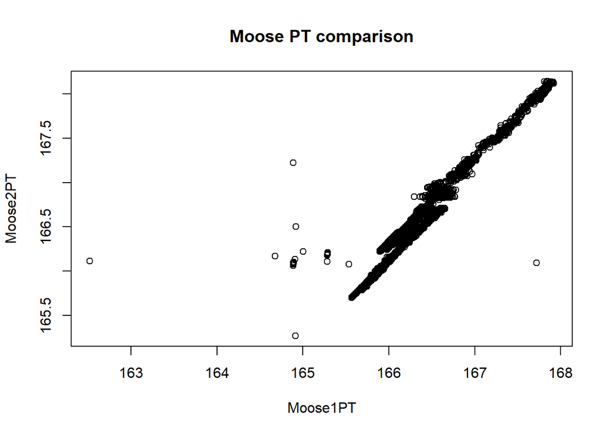

Some erroneous points but not bad. a slight shift

## Comparing FRCH

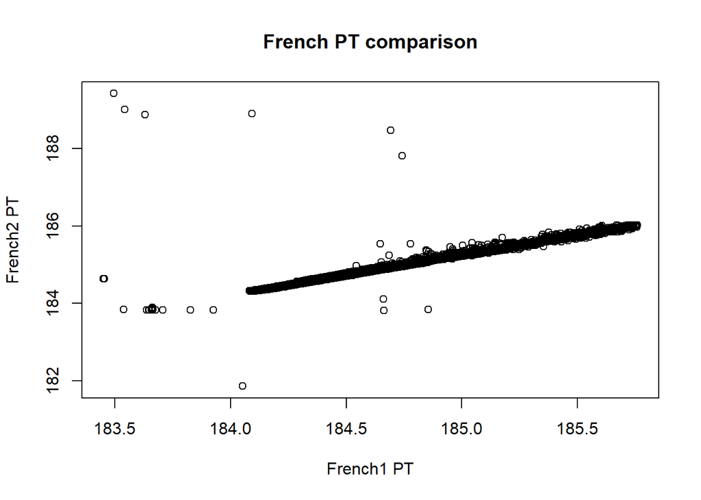

Pretty good, have to clean some of those points

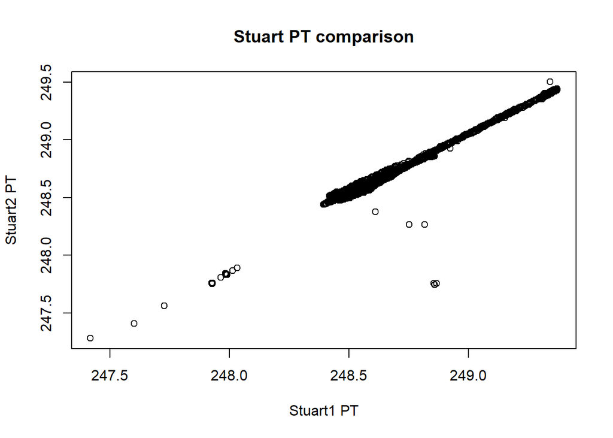

Same as French, some erroneous points that will need to be cleaned

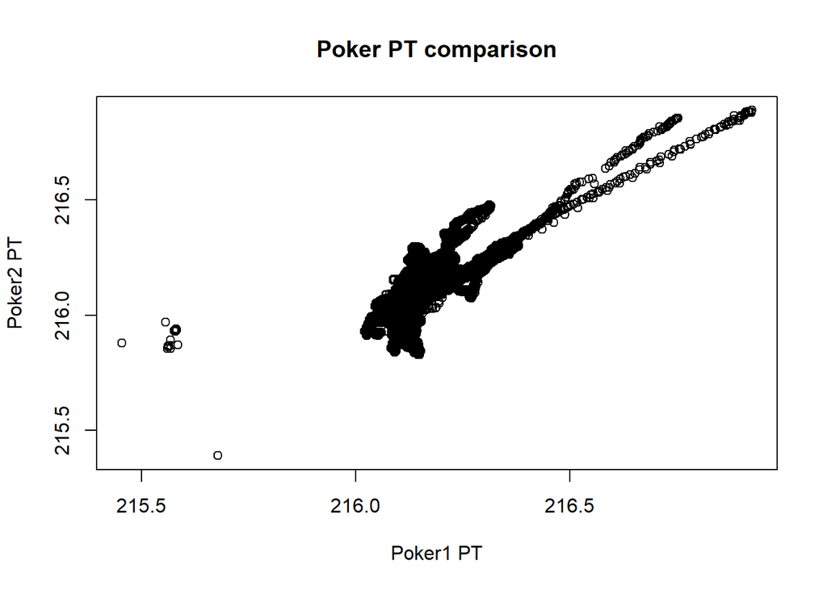

One PT is definitely more noisy

## Observed Discharge at all sites for 2020

Slugs and wading rods were used for 2020 observed Q

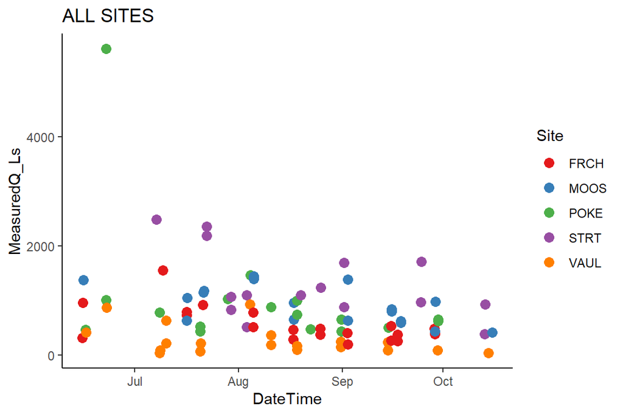

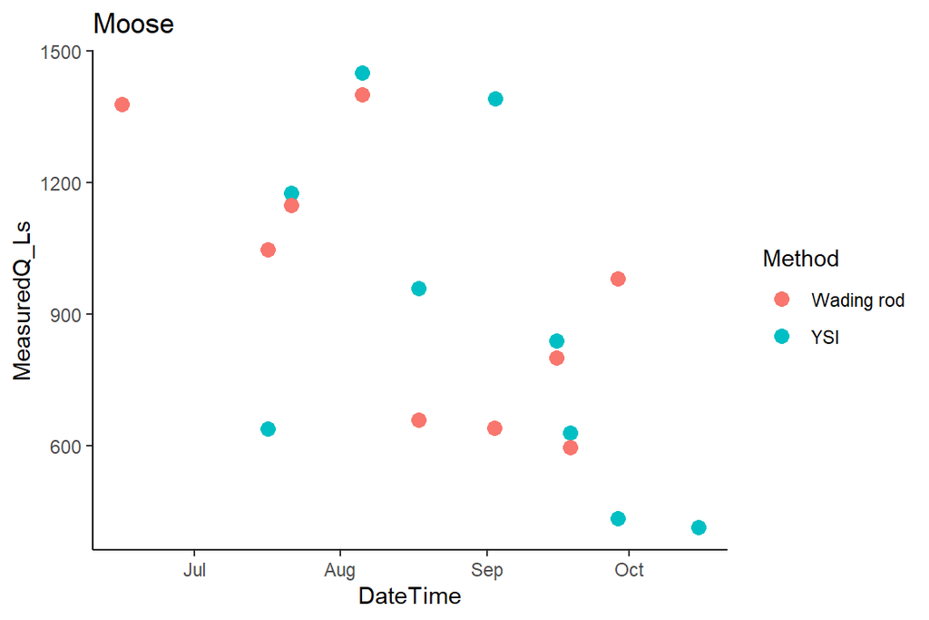

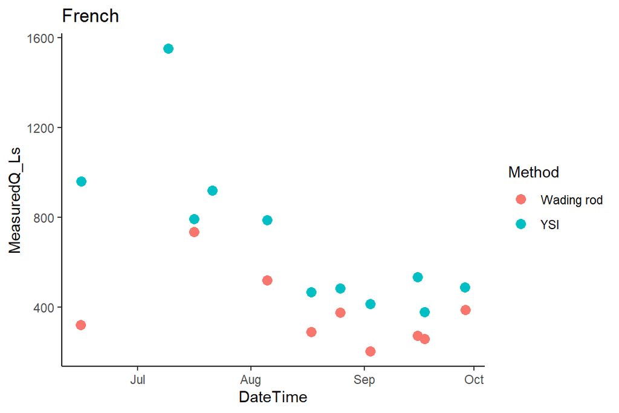

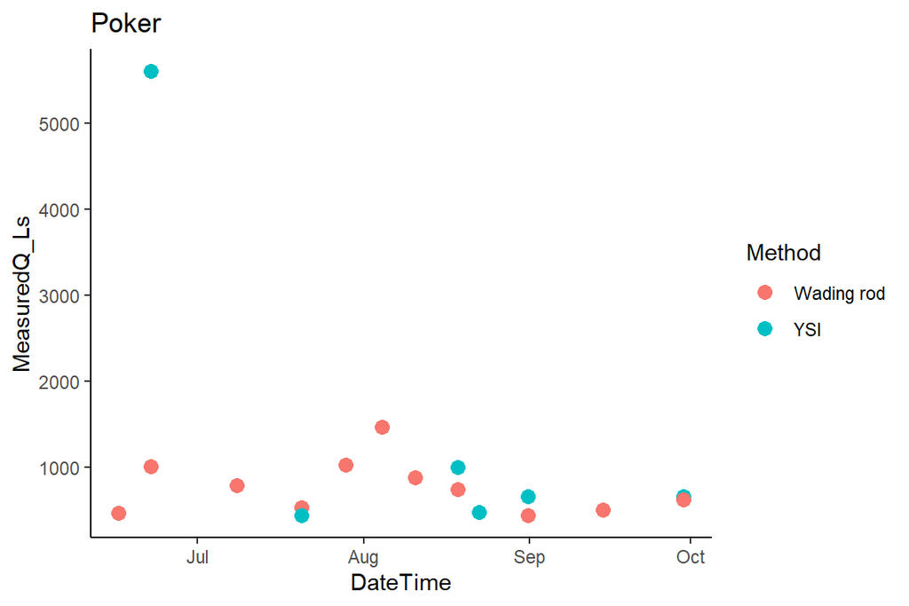

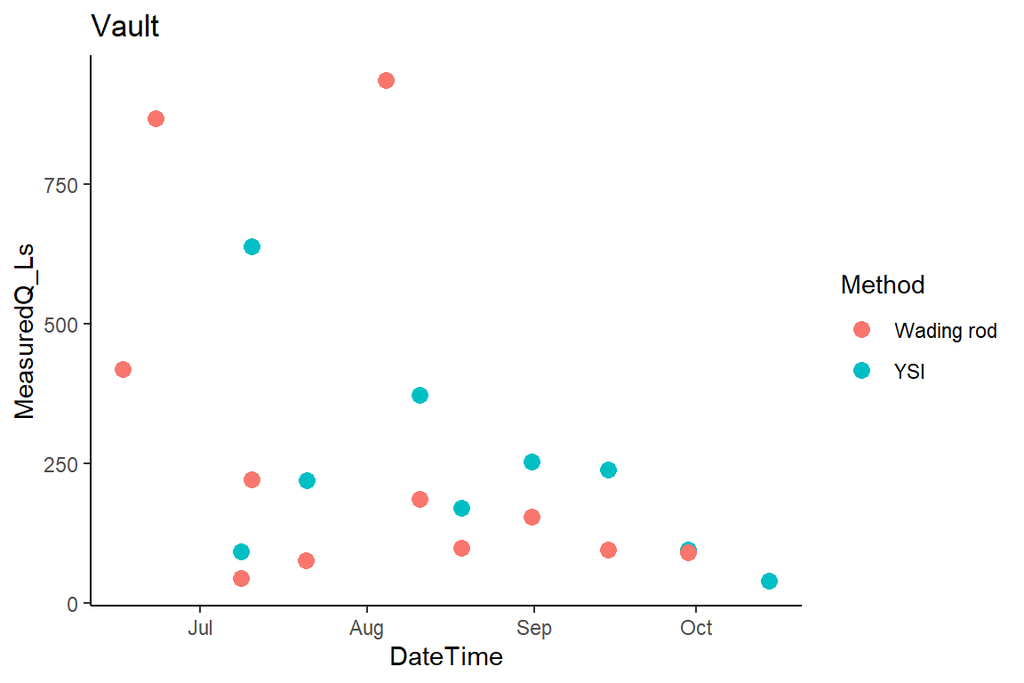

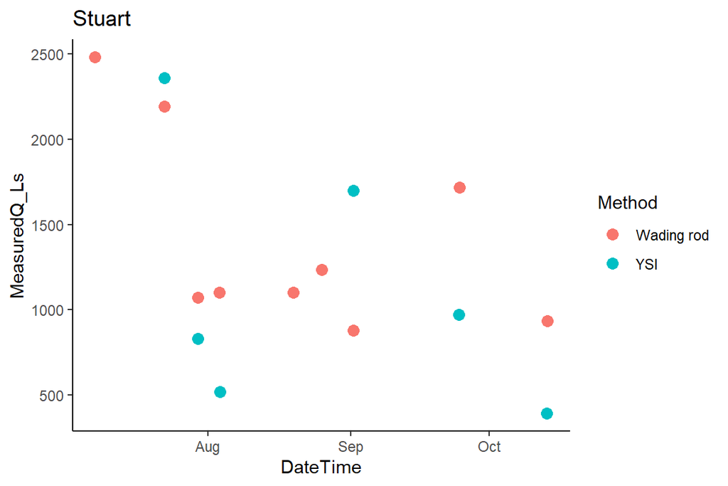

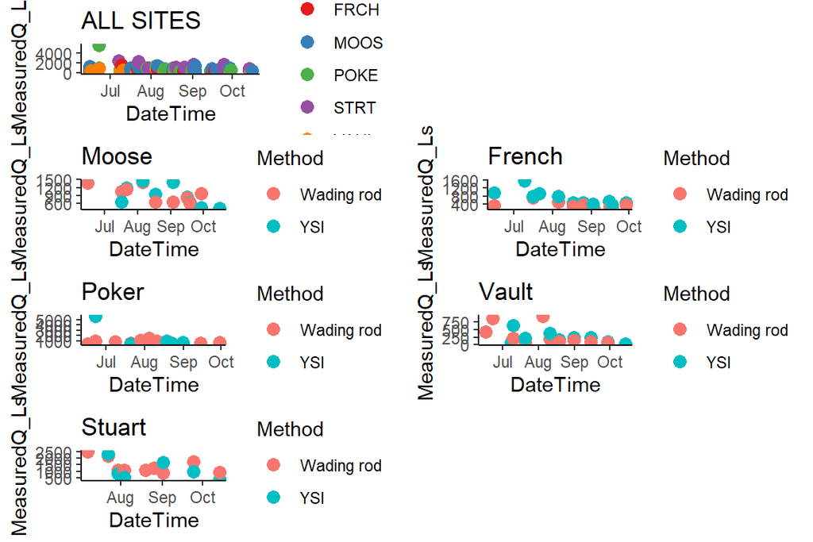

## Raw Moose PT1

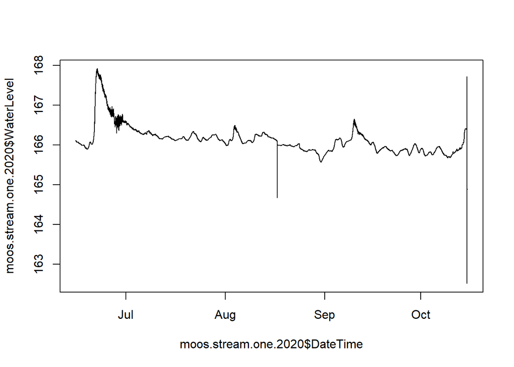

Noisy on the falling limb of first storm, potentially some out of water points in August and at the end of the season…Let the cleaning commence!

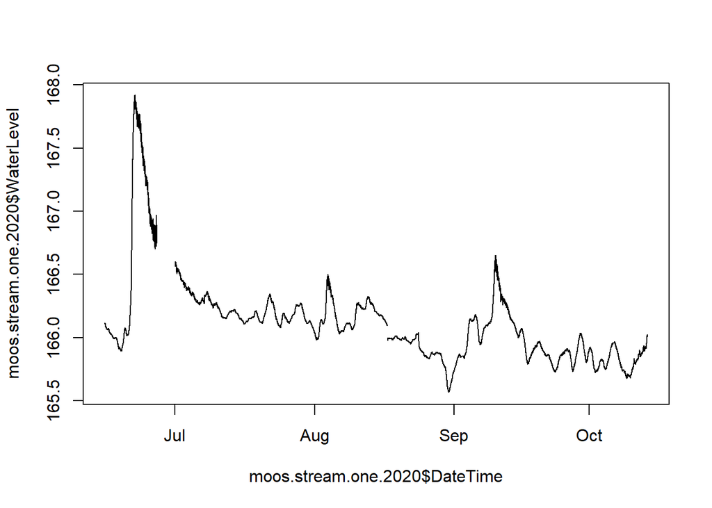

```
## [1] 166.093
```

```
## [1] 165.977
```

```
## [1] 0.116
```

[output not shown]

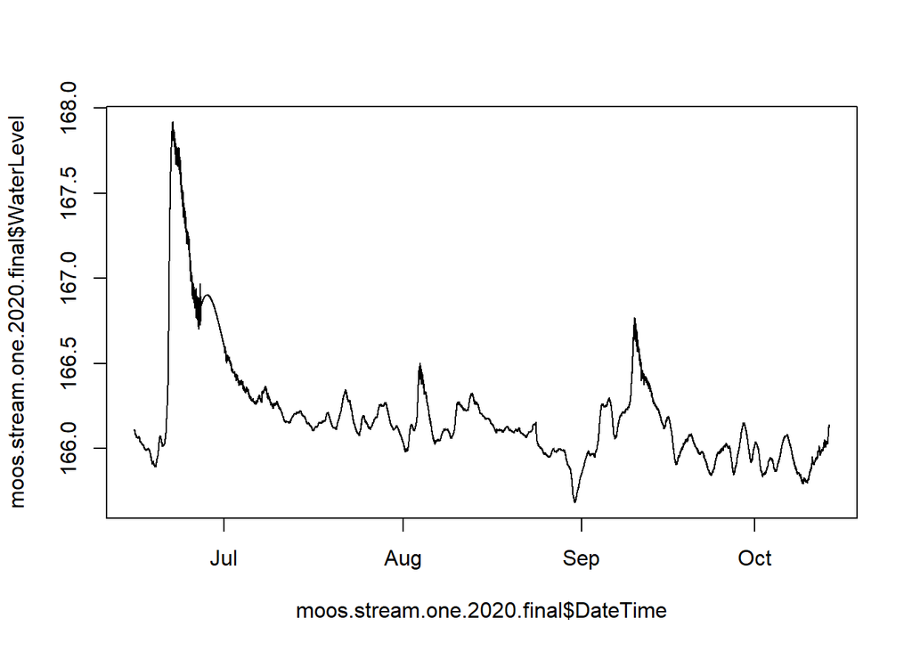

1. Clipped off data after 10/14 because thats when we took the PTs out
2. Set receding limb of first big storm in June to NA due to “noisy-ness”
3. clipped off errant points - vertical bars
4. After clipping off errant points the back half of the data after August 8/17 @ 07:00 needed to be shifted up so I took the difference of the not matched points of the data and added the difference to the data following the clip

## Raw Moose PT2

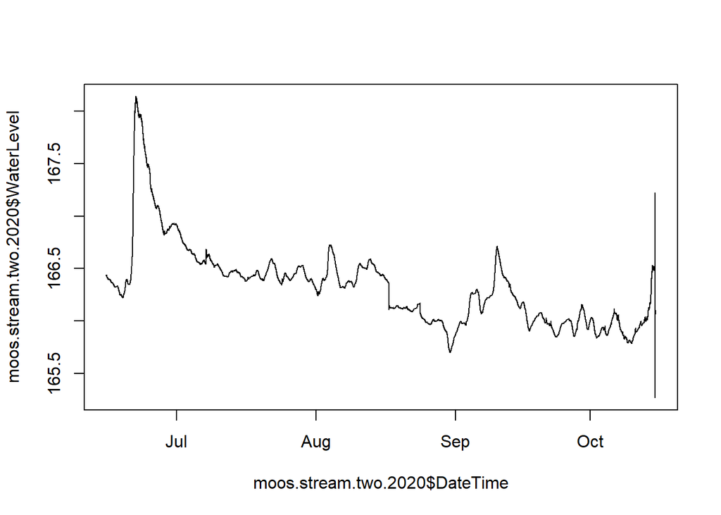

Need to adjust middle of August on and clip off out of water points associated with install or decomission

```
## [1] 166.361
```

```
## [1] 166.171
```

```
## [1] 0.19
```

[output not shown]

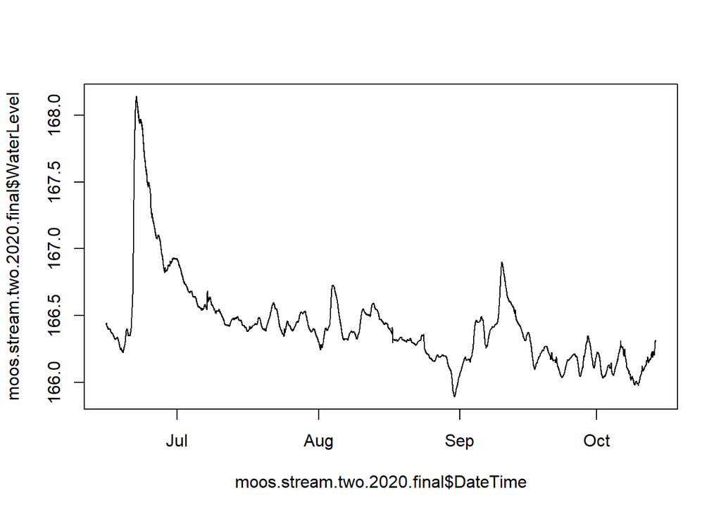

1. Clipped off data after 10/14 because thats when we took the PTs out
2. clipped off errant points (vertical bars)
3. After clipping off errant points the back half of the data after August 8/17 @ 07:00 needed to be shifted up so I took the difference of the not matched points of the data and added the difference to the data following the clip

Export PT data to csv in DoD_Discharge->PT_data->2020

Raw Rating Curve with MOOS PT1

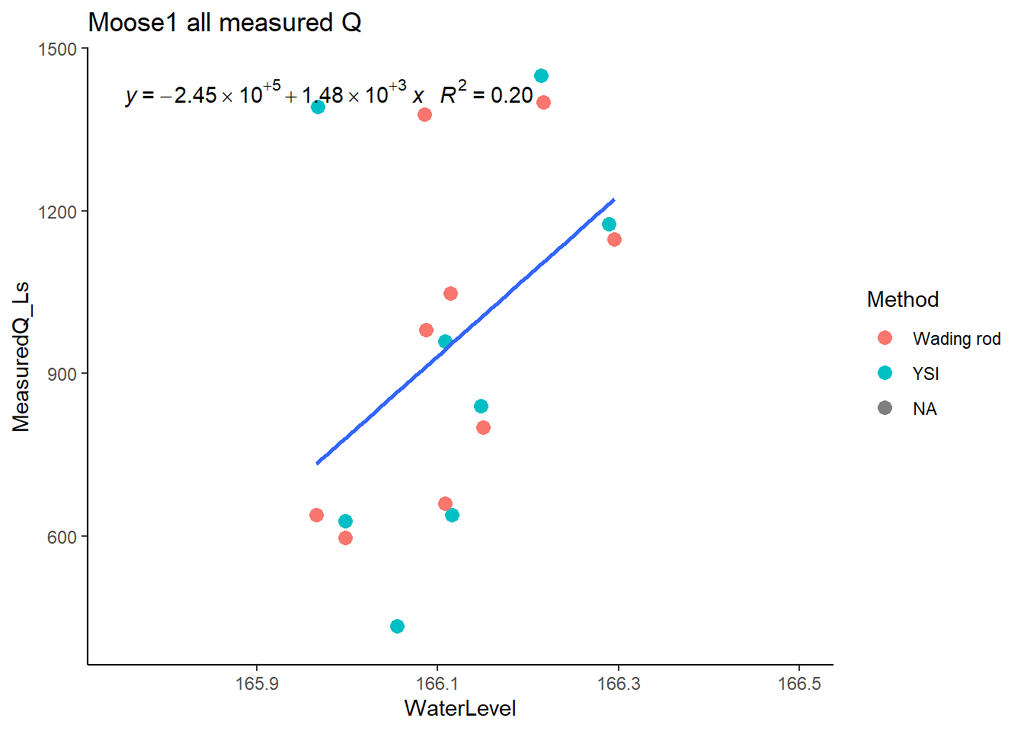

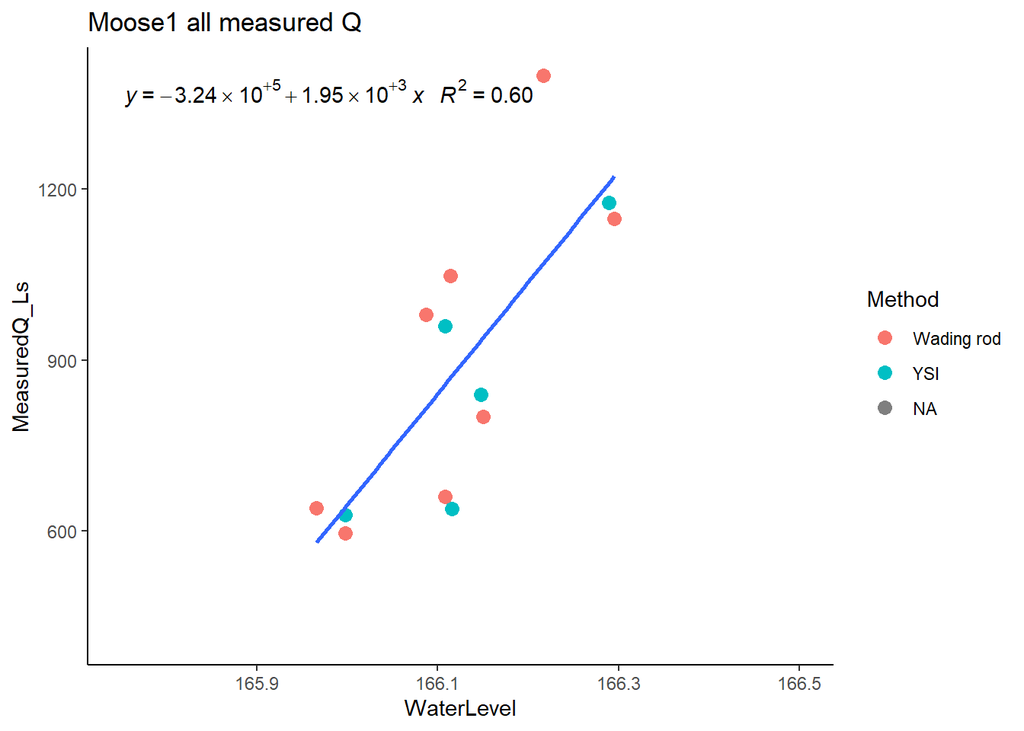

1. Removed the two highest YSI’s, lowest YSI and one of high flowmeter that wasnt a very high waterlevel

## Predict PT1 Q

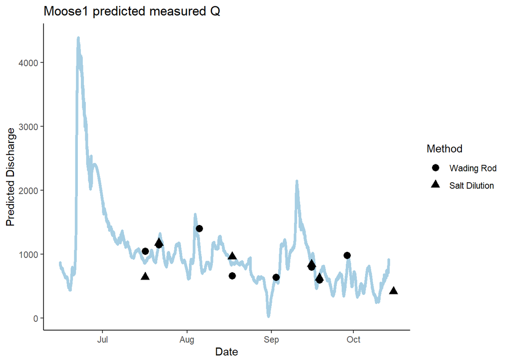

## Raw Rating Curve with MOOS PT2

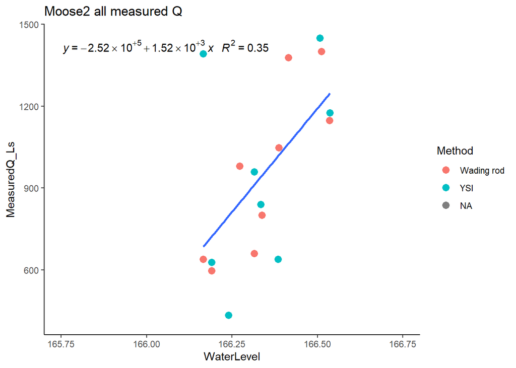

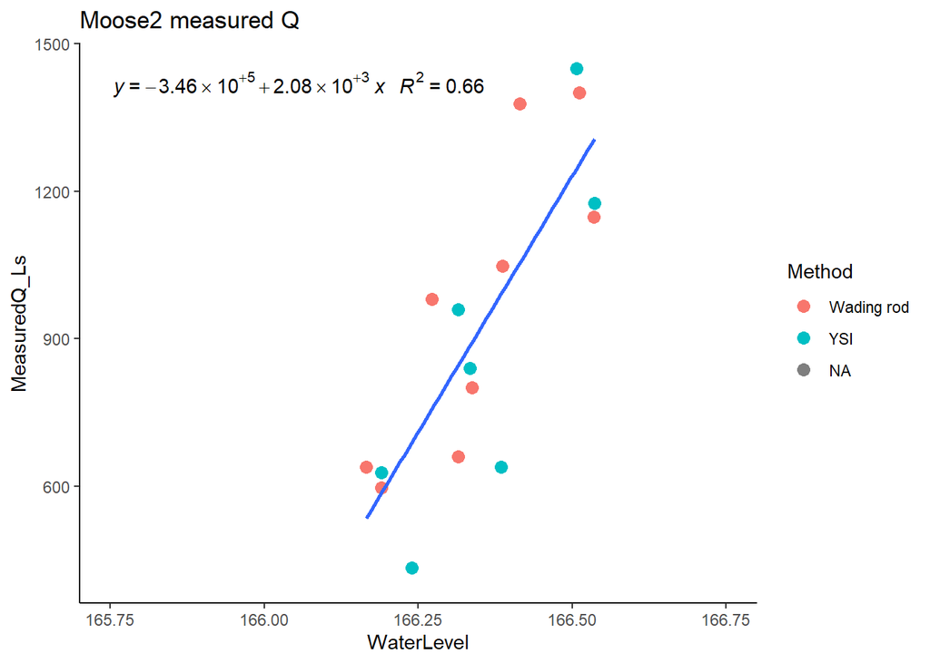

What about a curve with just wading rod points?

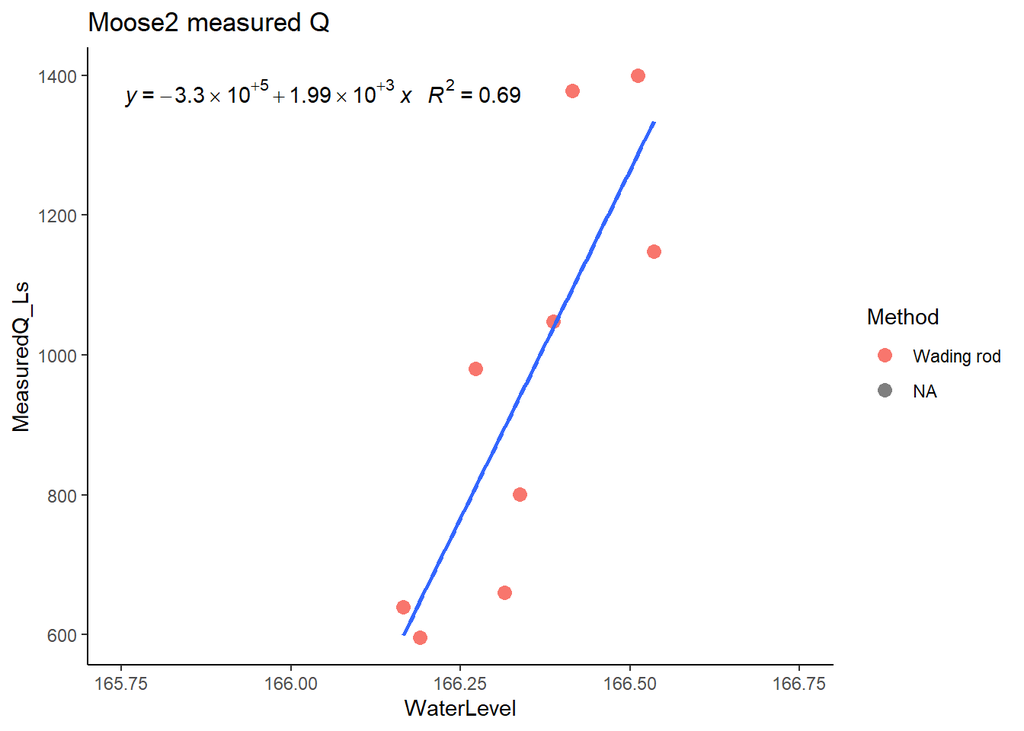

That looks the best for MOOS PT2

## Final Q for MOOS PT2

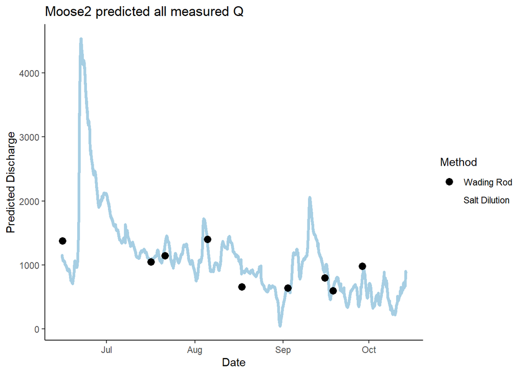

Looks pretty good

## Average of MOOS PT1 and PT2

```
##  [1] "Site.x"             "DateTimeGMT.x"      "AbsolutePressure.x"
##  [4] "WaterLevel.x"       "DateTime"           "WLB4.x"
##  [7] "Date.x"             "Time.x"             "Method.x"
## [10] "VolSlugml.x"        "Batch.x"            "MeasuredQ_Ls.x"
## [13] "date.x"             "pred.moos1.Q"       "Site.y"
## [16] "DateTimeGMT.y"      "AbsolutePressure.y" "WaterLevel.y"
## [19] "WLB4.y"             "Date.y"             "Time.y"
## [22] "Method.y"           "VolSlugml.y"        "Batch.y"
## [25] "MeasuredQ_Ls.y"     "date.y"             "pred.moos2.Q"
```

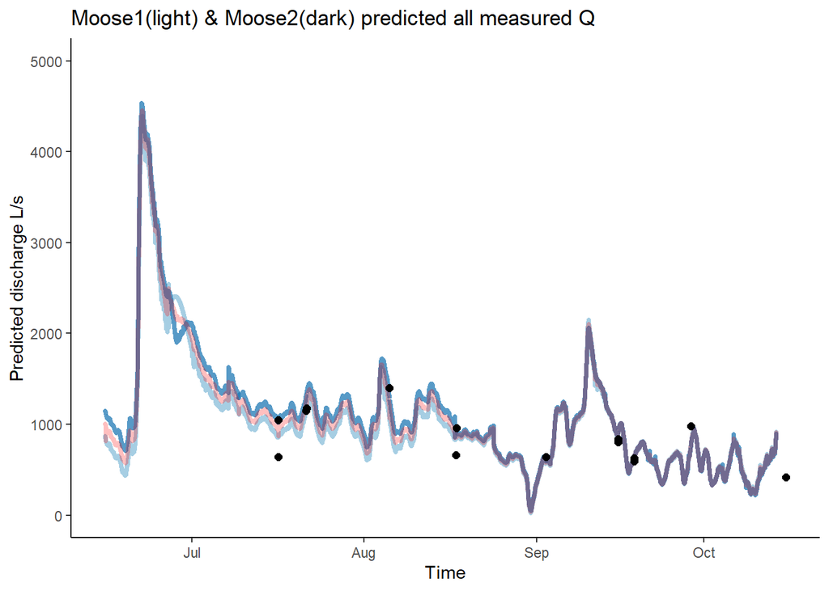

Red is the average that should be used and exported as csv.

##Export PT data to csv in DoD_Discharge->Predicted_Discharge->2020

# French

## Raw French PT1

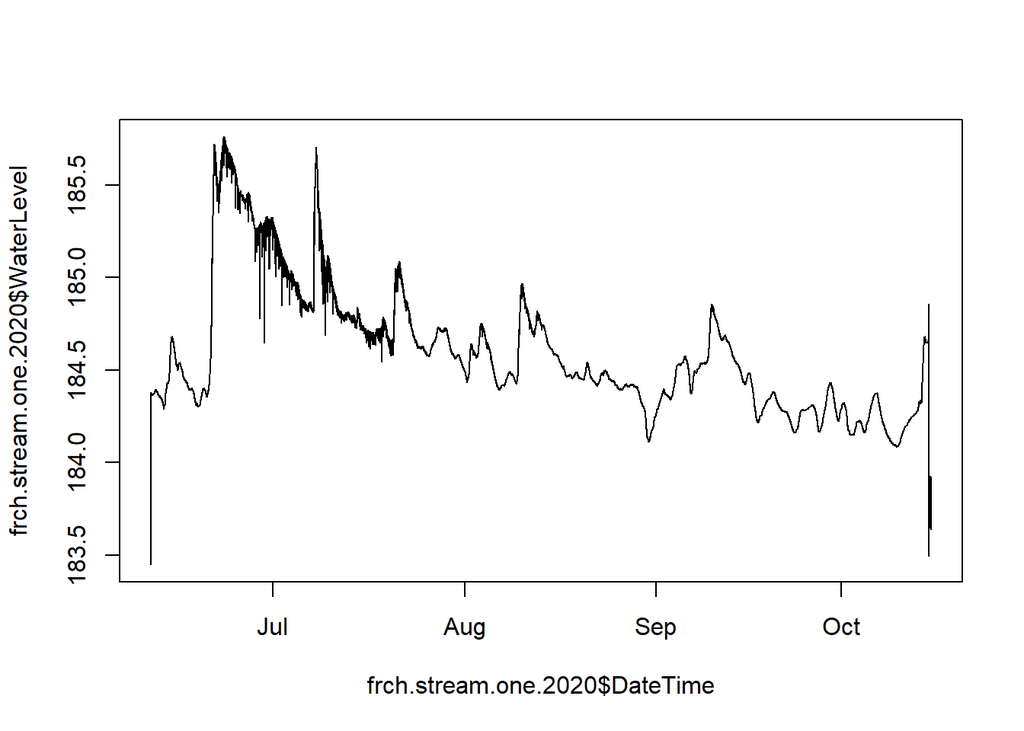

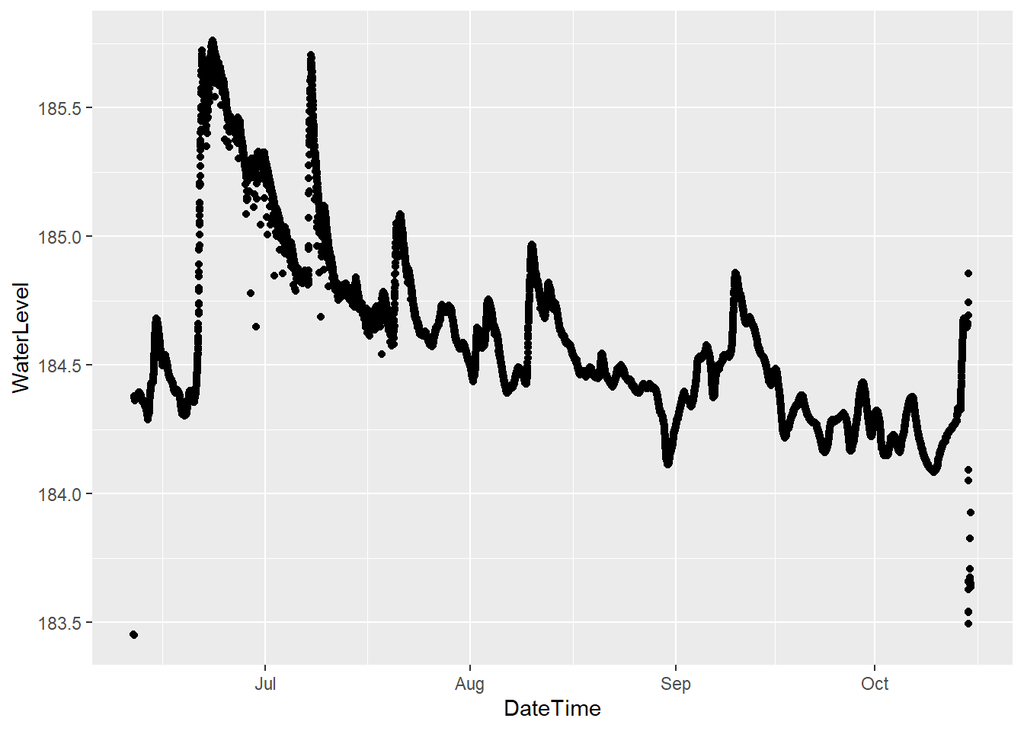

Needs cleaning for out of water points that are associated with install and decommission. Noisy on the falling limb of these storms! Let the cleaning commence!

## French PT1 2.0

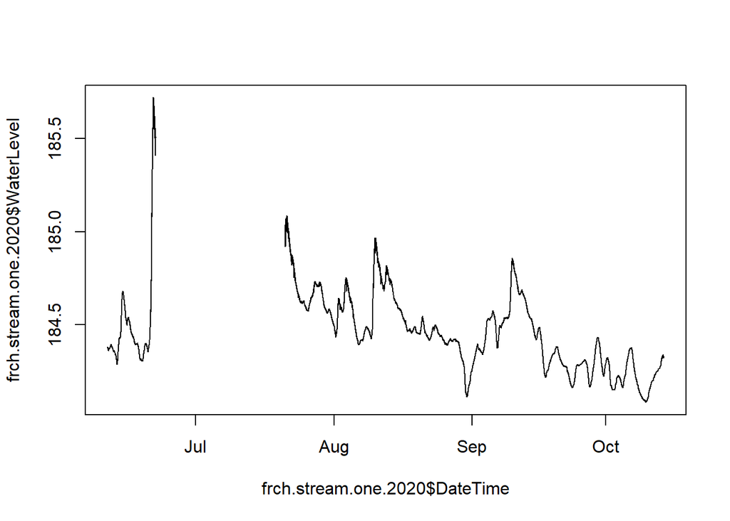

1. Removed points after October 14th (when we took out PTs) and out of water points in the beginning of the dataset
2. Removed noisy points on receding limb of big storm events in the beginning of the dataframe

## Raw French PT2

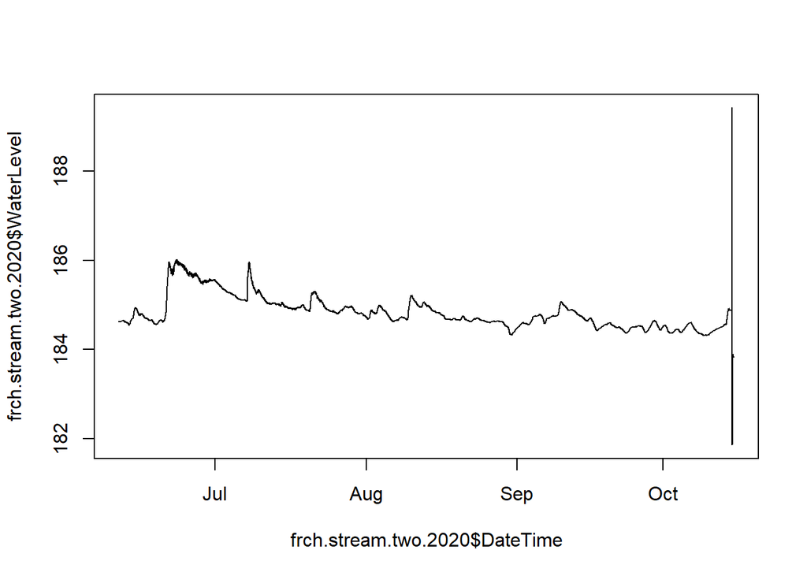

Receding limb of first initial storm is noisy on this one too

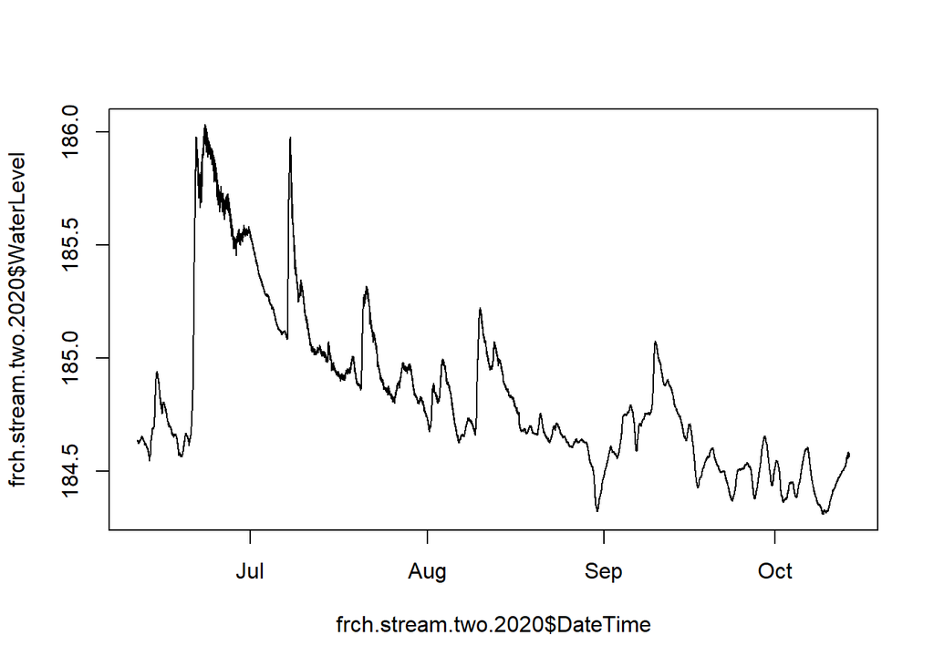

1. removed out of water points from taking out on the 14th of October

## Export PT data to csv in DoD_Discharge->PT_data->2020

## Raw Rating curve FRCH PT1

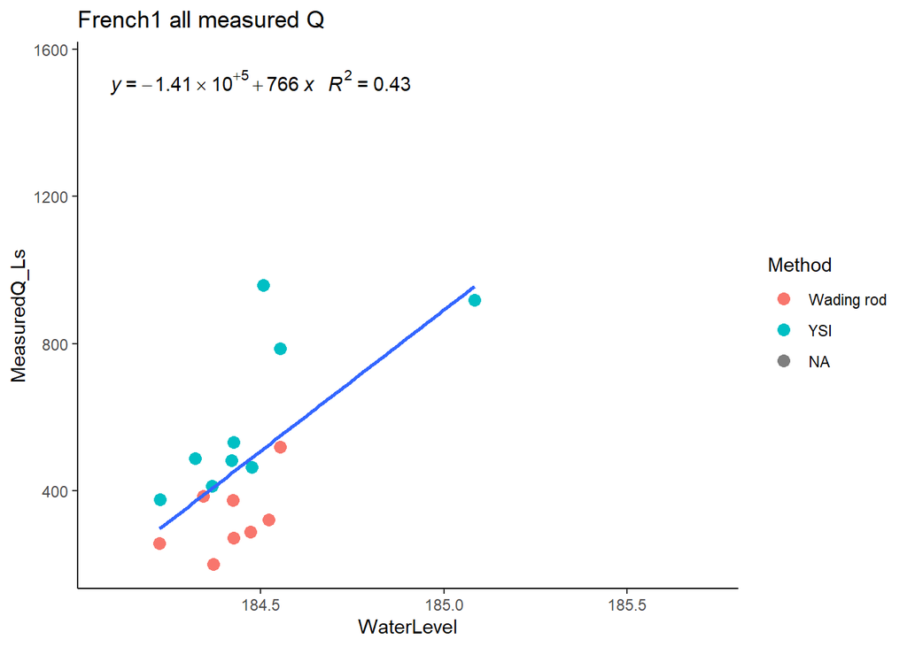

Lets remove two high YSI points.

```
##   Site         DateTimeGMT Absolute Pressure WaterLevel            DateTime
## 1 FRCH 07/09/20 5:15:00 PM           114.932         NA 2020-07-09 09:15:00
## 2 FRCH 07/16/20 6:45:00 PM           111.559         NA 2020-07-16 10:45:00
## 3 FRCH 07/21/20 6:00:00 PM           115.195    185.083 2020-07-21 10:00:00
##        Date  Time Method VolSlugml Batch MeasuredQ_Ls       date
## 1  7/9/2020  9:15    YSI      1000     B      1552.47 2020-07-09
## 2 7/16/2020 10:45    YSI      1000     B       791.43 2020-07-16
## 3 7/21/2020 10:00    YSI       500     J       919.03 2020-07-21
```

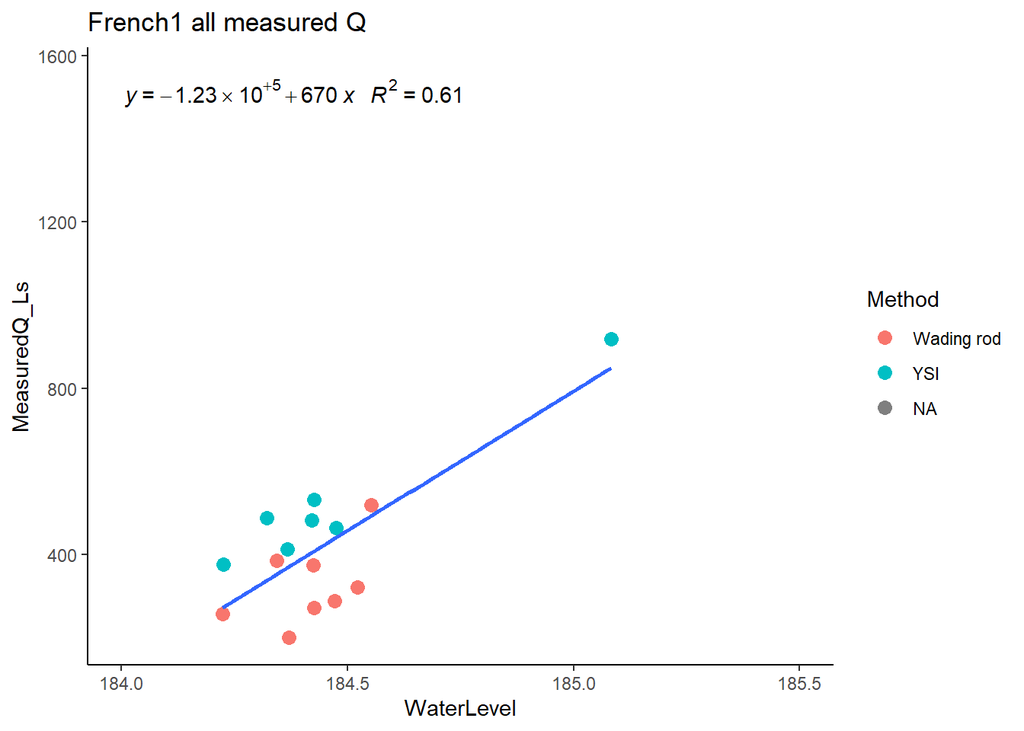

I would guess that the YSI is a little high and the wading rod is a little low. What if we average them by date? That may be more accurate than just taking the Wading rod points.

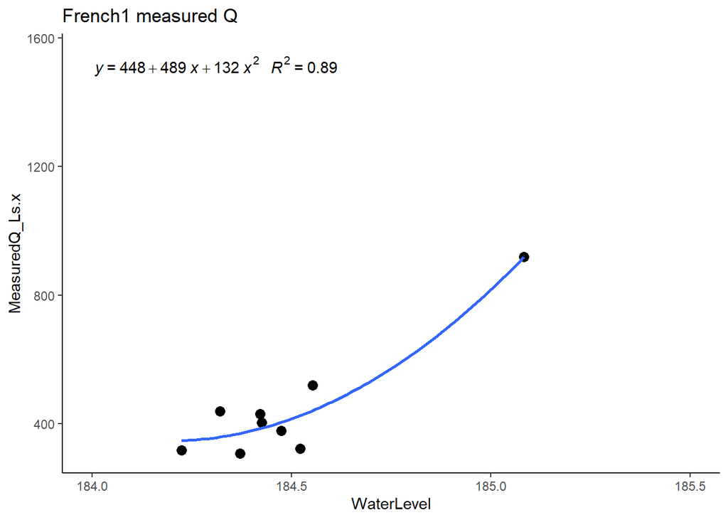

Seems reasonable. A quadratic relationship improved the R2.